[output not shown]

###### **Main contact for this notebook: Joy Kiarie (Joyce Kiarie <jckiarie@gmail.com)**

### 1. Course context

**Purpose and scope of this work**

There has been concerted efforts in modeling COVID-19 to describe its transmission dynamics. These models are either deterministic or stochastic, where there is only one exact solution and where there is a range of solutions respectively. An SEIR model for Kenya will be developed for COVID-19.

The specific aim for this work is to:

- implement in R deterministic SEIR model for COVID-19.
- implement in R stochastic SEIR model for COVID-19.

**Promoters**

- Prof. SM Mwalili (smwalili@strathmore.edu)
- Prof. Rachel Mbogo(rmbogo@strathmore.edu)

### 2. Background

**Mathematical models of infectious diseases**

We can divide infectious disease models into two broad classes:

- **Deterministic models** describe the infectious disease dynamics using a set of rate-based equations. These models are accurate in large populations where the population is approximately a continuum.
- **Stochastic models** allow for randomness, and account for the inherently discrete nature of populations of individuals. This makes stochastic models more realistic than deterministic ones, but also more challenging to analyse and implement.

With a large enough host population, the deterministic version approximates the average population dynamics. In this notebook we will introduce the basics of deterministic modelling.

**Compartmental models**

### 3. Determinstic SEIR without demography

**Model formulation**

```r
## Create an SEIR function
# Load deSolve library
library(deSolve)
library(ggplot2)
```

```r
# Set parameter values
beta1     <- .15
beta2     <- .08
omega     <- 0.196
delta     <- 85/100
gammaA    <- 1
gammaM    <- 0.9815
gammaH    <- 0.1
gammaC    <- 0.5
kappa     <- 0.044
zeta      <- 0.3
lambdaC   <- 0.25


S0  <- 995
E0  <- 2
A0  <- 1
M0  <- 0
H0  <- 0
C0  <- 0
D0  <- 0
R0  <- 0

N0  <- S0 + E0 + A0 + M0 + H0 + C0 + D0 + R0

init<-c(S0,E0,A0,M0,H0,C0,D0,R0)/N0

tt<-seq(0,210)

par0<-c(beta1 ,beta2 ,omega ,delta ,
        kappa ,gammaA ,gammaM ,gammaH,gammaC,zeta,lambdaC)
```

```r
## Solve using ode (General Solver for Ordinary Differential Equations)
output<-as.data.frame(ode(y=init,func = seir_ode,parms=par0,times = tt))
colnames(output)<- c("time","S","E","A","M","H","C","D","R")
out_long=melt(output,id="time")
```

```r
# To plot the proportion of susceptible, infected and recovered individuals over time
ggplot(data = out_long,
       aes(x = time, y = value, colour = variable, group = variable)) +
  geom_line() +xlab("Time (days)")+ylab("Proportion of the population") +
  scale_color_discrete(name="State")+ theme(text = element_text(size = 20)) +
  ylim(0, 1.00)
```

[output not shown]

### 4. Stochastic SEIR

$$\text{ Transition } \text{ Transition rate}\\\
(S, E) \to (S-1,E+1) \text{ at rate } \frac{\beta_1 S A}{N}+ \frac{\beta_2 S M}{N} \\
(E,A) \to (E-1,A+1) \text{ at rate } \delta \omega E \\
(E,M) \to (E-1,M+1) \text{ at rate } (1-\delta) \omega E \\
(A,R) \to (A-1,R+1) \text{ at rate } \gamma_A A \\
(M,R) \to (M-1,R+1) \text{ at rate } \gamma_M M \\
(M,H) \to (M-1,H+1) \text{ at rate } \kappa M \\
(H,R) \to (H-1,R+1) \text{ at rate } \gamma_H H \\
(H,C) \to (H-1,C+1) \text{ at rate } \zeta H \\
(C,R) \to (C-1,R+1) \text{ at rate } \gamma_C C \\
(C,D) \to (C-1,D+1) \text{ at rate } \lambda_C C\\$$

```r
# Set parameter values
beta1     <- .15
beta2     <- .08
omega     <- 0.196
delta     <- 85/100
gammaA    <- 1
gammaM    <- 0.9815
gammaH    <- 0.1
gammaC    <- 0.5
kappa     <- 0.044
zeta      <- 0.3
lambdaC   <- 0.25
N = 1e3                # Population size
A0 = 4                  # Initial number of infecteds
M0 = 1                  # Initial number of infecteds
```

In the next cell we declare the variables we need to track the time, the number of infecteds, the number or susceptibles, and the number of recovered individuals. These will update at each step of our simulation.

```r
t = 0                 # Current time
S = N - 5          # Current number of susceptibles
E = 10
A = A0          # Current number of infecteds assymp
M = M0           # Current number of infecteds symp
H = 0            # Current number of hosp
C = 0            # Current number of critically ill
D = 0            # Current number of deaths
R = 0                 # Current number of recovered individuals
```

Since we want to plot the evolutions of these variables, we store them in a dataframe (or lists, or arrays). We therefore prepare an empty dataframe to use as output of our model:

```
    df = data.frame()    # Output data (to be plotted later)
```

**Monte Carlo step**

In the next cell we set our rates based on the current state of the system, along with their sum.

```r
       rate  <- numeric(10)
        rate[1] = (beta1*S*A/N)+ (beta2*S*M/N)
        rate[2] = (delta*omega)
        rate[3] = (1-delta)*omega
        rate[4] = gammaA*A
        rate[5] = gammaM*M
        rate[6] = kappa*M
        rate[7] = gammaH*H
        rate[8] = zeta*H
        rate[9] = gammaC*C
        rate[10] = lambdaC*C
        rates = sum(rate)
        print(rates)
```

Provided the total rate is non-zero, we draw the “time to next event” from an exponential distribution and update the current time accordingly:

```r
if (rates > 0) {
            t = t + rexp(1,rates)
        }
```

If the next event happens after the total duration of the simulation, or if we have no more infecteds in the system, then we stop the simulation:

```
    if (t > totalTime || rates == 0){
        break;
    }
```

**Update**

Now that we know when the next event will happen, we draw a uniform random variable and use the “divided line” method to choose whether we get an infection or a recovery event:

```
    if (runif(1) < (rate[1]/rates)){#S-1,E+1
        S = S - 1
        E = E + 1
    } else if (runif(1) < (rate[2]/rates)){#E-1,A+1
          E = E - 1
          A = A + 1
        } else if (runif(1) < (rate[3]/rates)){#E-1,M+1
          E = E - 1
          M = M + 1
          } else if (runif(1) < (rate[4]/rates)){ #A-1,R+1
            A = A - 1
            R = R + 1
          } else if (runif(1) < (rate[5]/rates)){ #M-1,R+1
            M = M - 1
            R = R + 1
            } else     if (runif(1) < (rate[6]/rates)){ #M-1,H+1
                M = M - 1
                H = H + 1
                } else if (runif(1) < (rate[8]/rates)){ #H-1,R+1
                    H= H - 1
                    R = R + 1
                    } else if (runif(1) < (rate[7]/rates)){ #H-1,C+1
                      H= H - 1
                      C = C + 1
                      } else if(runif(1) < (rate[9]/rates)){ #C-1,R+1
                          C = C - 1
                          R= R + 1
                          }
                          else{ #C-1,D+1
                          C = C - 1
                          D = D + 1
                          }
```

We then store the new counts into the output dataframe that we prepared:

```
    df = rbind(df,data.frame(times=t,S=S,E=E,Ia=Ia,Im=Im,H=H,C=C,D=D,R=R))
```

### Gillespie function

**Preparing the Gillespie function**

##### *$\rightarrow$Try it yourself*

We can combine the previous cells into a function that we call `Gillespie()`.

```r
# Recalling the needed parameters
totalTime =200 # Total simulation time in days
beta1     <- .15
beta2     <- .08
omega     <- 0.196
delta     <- 85/100
gammaA    <- 1
gammaM    <- 0.9815
gammaH    <- 0.1
gammaC    <- 0.5
kappa     <- 0.044
zeta      <- 0.3
lambdaC   <- 0.25
N = 1e3                 # Population size
A0 = 4                  # Initial number of infecteds
M0 = 1                  # Initial number of infecteds


# declaring the Gillespie function
Gillespie = function() {
  t = 0 # Current time
  S = N - 5 # Current number of susceptibles
  E = 5
  A = A0 # Current number of infecteds assymp
  M = M0 # Current number of infecteds symp
  H = 0 # Current number of hosp
  C = 0 # Current number of critically ill
  D = 0 # Current number of deaths
  R = 0 # Current number of recovered




  df = data.frame() # Output data(to be plotted later)
  i = 0
  while (isTRUE(t < totalTime)) {
    i = i + 1
    df = rbind(df, data.frame(times = t, S = S, E = E,
                              A = A,
                              M = M, H = H, C = C, D=D,R = R))
    # Monte Carlo step
    # rate <- numeric(10)
    #    rate  <- numeric(10)
    #     rate[1] = (beta1*S*A/N)+ (beta2*S*M/N)
    #     rate[2] = (delta*omega)*E
    #     rate[3] = (1-delta)*omega*E
    #     rate[4] = gammaA*A
    #     rate[5] = gammaM*M
    #     rate[6] = kappa*M
    #     rate[7] = gammaH*H
    #     rate[8] = zeta*H
    #     rate[9] = gammaC*C
    #     rate[10] = lambdaC*C
    #     rates = sum(rate)



        rate  <- numeric(10)
        rate[1] = (beta1*S*A/N)+ (beta2*S*M/N)
        rate[2] = (delta*omega)*E
        rate[3] = (1-delta)*omega*E
        rate[4] = gammaA*A
        rate[5] = gammaM*M
        rate[6] = kappa*M
        rate[7] = gammaH*H
        rate[8] = zeta*H
        rate[9] = gammaC*C
         rate[10] = lambdaC*C
        rates = sum(rate)


    if (rates > 0) {
       t = t + rexp(1, rate = rates)
    }

    if (isTRUE(t > totalTime) || rates == 0) {
      break
    }

    # # Update
        if (runif(1) < (rate[1]/rates)){#S-1,E+1
            S = S - 1
            E = E + 1
        } else if (runif(1) < (rate[2]/rates)){#E-1,A+1
              E = E - 1
              A = A + 1
            } else if (runif(1) < (rate[3]/rates)){#E-1,M+1
              E = E - 1
              M = M + 1
              } else if (runif(1)< (rate[4]/rates)){ #A-1,R+1
                A = A - 1
                R = R + 1
              } else if (runif(1) < (rate[5]/rates)){ #M-1,R+1
                M = M - 1
                R = R + 1
                } else     if (runif(1) < (rate[6]/rates)){ #M-1,H+1
                    M = M - 1
                    H = H + 1
                    } else if (runif(1)  < (rate[7]/rates)){ #H-1,R+1
                        H= H - 1
                        R = R + 1
                        } else if (runif(1) < (rate[8]/rates)){ #H-1,C+1
                          H= H - 1
                          C = C + 1
                          } else if(runif(1) < (rate[9]/rates)){ #C-1,R+1
                              C = C - 1
                              R= R + 1
                              }
                              else  if(runif(1) < (rate[10]/rates)){ #C-1,D+1
                              C = C -1
                              D = D +1
                              }
    }
   return (df)
}
```

**Plotting the results**

```r
# call the function and store the results in lists
#results = Gillespie()
#  head(results, n = 20L)
#  tail(results, n = 20L)

# plotting
plot(results$times,results$S,type='s',col='blue',bty="n",ylab="Number of individuals",xlab="time",lwd=2,ylim=c(0,N))
lines(results$times,results$E,type='s',col='orange',lwd=2)
```

```r
lines(results$times,results$A,type='s',col='red2',lwd=2)
lines(results$times,results$M,type='s',col='yellow',lwd=2)
```

```r
lines(results$times,results$C,type='s',col='black',lwd=2)
lines(results$times,results$R,type='s',col='green',lwd=2)
```

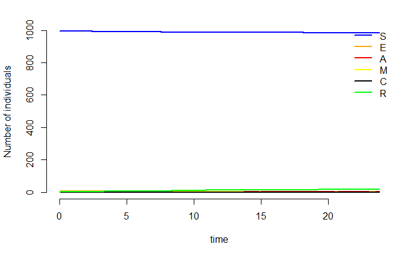

```r
legend(x="topright",c("S","E","A","M","C","R"),lty=1,col=c("blue","orange", "red2","yellow","black","green"),bty="n",lwd=2)
```